# 第10回 順伝播ニューラルネットワーク②（過学習と早期終了・重み減衰・ハイパーパラメータ調整）

経済データとプログラミングII

第10回

順伝播ニューラル  
ネットワーク②

回しすぎを止め、重みに罰金を掛け、設定を交差検証で選ぶ

経済データとプログラミングII

第10回 — Topic01

ニューラルネットの過学習  
と早期終了

検証の損失が底を打ったところで止める

## 第10回の道のり

1

見つけて止める

実習：実行 データを読む準備

実習：実行 分けてそろえる準備

実習：実行 学習曲線の準備

演習 10-1 学習曲線の読み取り

実習：写経 早期終了の 3 つの引数

2

罰金を掛ける

実習：写経 罰金つきの学習

演習 10-2 罰金の強さの変更

3

選んで比べる

実習：実行 候補と道具の準備

実習：写経 グリッドサーチ

演習 10-3 Ridge の α の選択

いまココ。NN を回し続けると何が起きるかを見る

## 前の回の振り返り

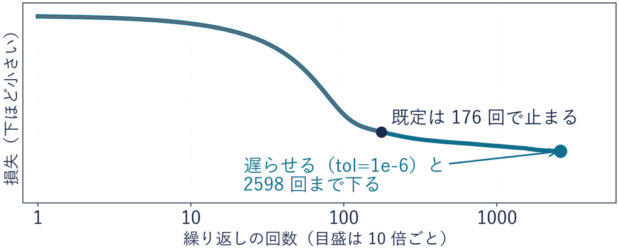

**前の回**：`MLPRegressor` の損失曲線は、回すほど下がった  
既定のまま止めると、まだ下る途中だった

**残した話**：残る数が 3 つ（重み 2 つとバイアス）なら 497 か月は覚えようがない  
重みの数が桁違いに多いと、話が少し変わる

## このトピックで学ぶこと

- **ここまで**：損失曲線は、回すほど下がった（前の回）
- **でも**：下がったのは、答えを知っている手元の月の損失だけ  
  来月を当てたいのに、  
  見ていない月で当たるかは分からない（前に見た過学習）
- **問い**：NN を回し続けるのは、良いことか
- **進め方**：前半は 5 人の表（E さんを隠す）、後半で景気動向指数

そこで、見ていないデータの損失も、1 周ごとに測る

## E さんを隠した 4 人の NN

いつもの 5 人で E さんを隠し、A〜D の 4 人だけで NN を 1 周ずつ回す  
（隠れ層のノード 10 個・前の回の `MLPRegressor`。1 周＝4 人を 1 回ずつ使って重みを動かすこと）

[figure not shown]

35 周では E さんの見込みは 3.0 時間。回しきると −2.0 時間（実際は 3 時間）  
D さん（4 日・2 時間）から 1 日で 4 時間下がる線を、そのまま延ばした形

## ◼ 学習曲線

**学習曲線：回した回数ごとに、訓練と検証の損失を並べた 2 本の線**

[figure not shown]

**周（エポック）**：学ぶデータを、全部 1 回ずつ使い切ること  
前の回の「繰り返しの回数」と同じ数え方

**検証データ**：学ぶのに使わず、途中の当たりを見張る分（ここでは E さん）  
何周で止めるかを選ぶのに使う。テストは最後の採点だけ

訓練の損失は 0 へ下がり続ける。E さんの損失は 35 周で底を打って上がる  
5 人では人数が足りないので E さんが検証役。実データでは検証 75 か月とテストを分ける

## ◼ 早期終了

**早期終了：回しすぎて覚える前に、検証の底で止める**

手順

STEP 1：1 周ごとに検証の損失を測り、それまでの底を覚えておく

STEP 2：底を更新しない周が、決めた周数（ここでは 20 周）続くまで回す

STEP 3：止めて、底の周の重みに戻す（止めた周の重みは回しすぎ）

[figure not shown]

前の回は、止めるのが早すぎて損をした。今度は回しすぎ。どちらも曲線を見て決める

## ✋ たしかめ 景気動向指数の 1500 周

たしかめ

今度は景気動向指数で。1500 周回すと、2 本の線は

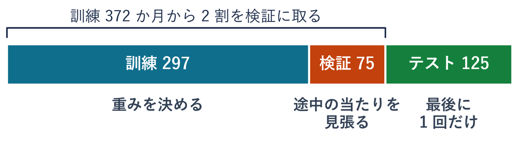

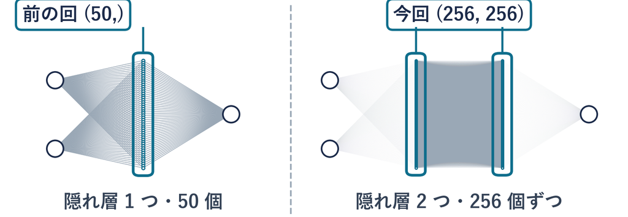

ネットワーク：隠れ層 2 つ・ノード 256 個ずつ（前の回より大きい）・学習率 0.01・罰金なし

**ⓐ** 両方下がり続ける **ⓑ** 訓練は下がり検証は途中で上がる **ⓒ** 両方途中で横ばい

⏸ PAUSE 動画を止めて $1$ 分。選んだら再生に戻る

## ★ 景気動向指数の学習曲線

たしかめの答えは **ⓑ**。検証の底（133 周）で訓練は 3.68。そこから約 1 まで下がり続ける

[figure not shown]

検証は 133 周で底 6.87 を打ち、1500 周では 10 前後まで上がる。2 本の線が開いていく  
線のぎざぎざは、1 周ごとに重みが動くため。全体の向きで読む

## ★ 底で止めた場合と回しきった場合

**早期終了：回しすぎて覚える前に、検証の底で止める**

[figure not shown]

**底で止める**：テストの MSE 6.01

**回しきる**：約 10。重回帰の 10.43 と同じくらいまで悪くなる

**覚えられる訳**：重みとバイアスは 66,817 個、学ぶ月は 297 か月（約 225 倍）  
前の回の「残ったのは 3 つの数」（重み 2 つとバイアス）とは桁が違う

## よくある失敗 訓練の損失だけによる判断

✕ 訓練の損失が下がった＝賢くなった

前の回、  
損失が下がるのが学習と言った  
だから 1 まで下がれば、  
賢くなったように見える

○ 2 本を並べて初めて分かる

訓練が約 1 まで下がったとき  
テストは重回帰と同じ  
くらいまで悪い

訓練の線だけでは、学んだのか覚えたのか分からない。  
検証の線を並べて初めて分かる

## データを読む準備のセル

```python
!pip install -q japanize-matplotlib
import japanize_matplotlib
import numpy as np
import pandas as pd
import matplotlib.pyplot as plt
from sklearn.model_selection import train_test_split
from sklearn.preprocessing import StandardScaler
from sklearn.neural_network import MLPRegressor
from sklearn.linear_model import LinearRegression
from sklearn.metrics import mean_squared_error
BASE = "ここに manaba の URL を貼る"
ci = pd.read_csv(BASE + "ci_composite.csv").dropna()
X = ci[["ci_leading", "ci_lagging"]]
y = ci["ci_coincident"]
print(len(ci))
```

ノートの準備のセル（写さず実行）。先に `BASE` の行の引用符の中を、  
manaba に載せた URL の最後の `/` までに書き換える  
前の回と同じデータ。入力 `X` は先行・遅行、答え `y` は一致。`497` と出る

## 分けてそろえる準備のセル

```python
Xtr, Xte, ytr, yte = train_test_split(X, y, test_size=0.25,
                                      random_state=42)
sx = StandardScaler().fit(Xtr)
sy = StandardScaler().fit(ytr.to_frame())
def mse_of(model, Xp, yp):
    pred = model.predict(sx.transform(Xp)).reshape(-1, 1)
    return mean_squared_error(yp, sy.inverse_transform(pred).ravel())
lin = LinearRegression().fit(Xtr, ytr)
mse_lin = mean_squared_error(yte, lin.predict(Xte))
print(len(Xtr), len(Xte), round(mse_lin, 2))
```

ノートの準備のセル（写さず実行）  
前の回の最後と同じ分け方・そろえ方（訓練 372・テスト 125）。  
2 行目の 42 は混ぜるくじの番号  
5〜7 行の `mse_of` は、見込みを元の単位に戻して MSE を測る  
`372 125 10.43` と出る（10.43 は重回帰のテスト）

## 学習曲線の準備のセル

```python
Xf, Xv, yf, yv = train_test_split(Xtr, ytr, test_size=0.2,
                                  random_state=0)
sf = StandardScaler().fit(Xf)
mf, s_f = yf.mean(), yf.std(ddof=0)
def loss(mlp, A, b):
    return mean_squared_error(b, mlp.predict(sf.transform(A)) * s_f + mf)
def learn(epochs, seed=0):
    mlp = MLPRegressor(hidden_layer_sizes=(256, 256), alpha=0,
                       learning_rate_init=0.01, random_state=seed)
    tr, va = [], []
    for _ in range(epochs):
        mlp.partial_fit(sf.transform(Xf), (yf - mf) / s_f)
        tr.append(loss(mlp, Xf, yf))
        va.append(loss(mlp, Xv, yv))
    return tr, va
print(len(Xf), len(Xv))
```

ノートの準備のセル（写さず実行）。訓練 372 の 2 割（75 か月）を検証に取り、  
そろえ方は残る 297 か月だけで決める  
`learn` は 1 周ずつ学び（`partial_fit`）、  
そのたびに訓練と検証の損失を測って並べる。`297 75` と出る

## 演習 10-1 学習曲線の読み取り

演習 10-1

最初の重みのくじを 1 に替えると、検証の底は何周目あたりか

```python
tr, va = learn(1500, seed=1)
plt.plot(tr, label="訓練")
plt.plot(va, label="検証")
plt.legend()
plt.show()
print(np.argmin(va) + 1, round(min(va), 2))
```

1. **先に考える**：くじ 0 の底は 133 周。くじ 1 では ⓐ 同じくらい ⓑ 早い ⓒ 遅い
2. **写して実行**：上の 6 行を新しいセルで実行（1500 周なので少し待つ）
3. **終わり**：答え欄に ⓐ〜ⓒ と、出た 2 つの数（底の周・底の損失）

⏸ PAUSE 動画を止めて $3$ 分。答えを書いたら再生に戻る

## 演習 10-1 の答え

答えは **ⓑ 早い**。出力は `75 7.34`（75 周で底 7.34）  
75 は周の数。検証の 75 か月とはたまたま同じ数

**くじ 0**：133 周で底 6.87

**くじ 1**：75 周で底 7.34

**分かること**：底の周は、最初の重みのくじで動く  
何周回すかを先に決め打ちできない

だから周の数は決めず、検証を見張って自動で止めたい（早期終了）

## 既定の打ち切りの見張り先

`MLPRegressor` には、もともと打ち切りがある（前の回の `tol`）。違うのは見張る相手

|  | 見張るもの | 止まる所 |
| --- | --- | --- |
| **既定のまま** | 訓練の損失の下り | くじ 10 通りで 56〜150 周 |
| **`early_stopping=True`** | 検証の当てはまり | 底を更新しない周が 20 周を超えたら止める |

既定の止まり方は、訓練の下りが小さくなったら止まるだけ。  
検証の底と合うのはたまたま

## 写経 1 早期終了の 3 つの引数

```python
mlp = MLPRegressor(hidden_layer_sizes=(256, 256), alpha=0,
                   learning_rate_init=0.01, random_state=0,
                   early_stopping=True, validation_fraction=0.2,
                   n_iter_no_change=20)
mlp.fit(sx.transform(Xtr), sy.transform(ytr.to_frame()).ravel())
print(mlp.n_iter_, round(mse_of(mlp, Xte, yte), 2))
```

| 行 | 部品 | 渡すもの | できるもの |
| --- | --- | --- | --- |
| 1-2 | **作る** `MLPRegressor` | 隠れ層 2 つ・ノード 256 個ずつ・ 学習率 0.01 | モデル `mlp` |
| 3-4 | **早期終了の 3 つ** | 検証を見張る・訓練の 2 割を 検証に・20 周待つ | ぎざぎざで止まらない止め時 |
| 5 | **学ぶ** `.fit` | そろえた訓練 372 か月 | 底の周の重み |
| 6 | **見る** | 止まった周・テストの MSE | `49 6.08` |

※ `alpha=0` は罰金なし  
※ 28 周目の底から 20 周を超えた 49 周目で止まり、28 周目の重みに戻る  
※ 検証の 2 割は自分で選ぶので、底の周も 133 と違う

## コードセルの写経と実行

1. **＋ コード**で空のセルを足す  
   （案内の文の下）
2. 写経 1 の 6 行を上  
   から写す
3. **▶** か **Shift + Enter** で実行  
   （Mac は Shift + return）
4. 止まった周 49 と、  
   テストの MSE 6.08 を見る

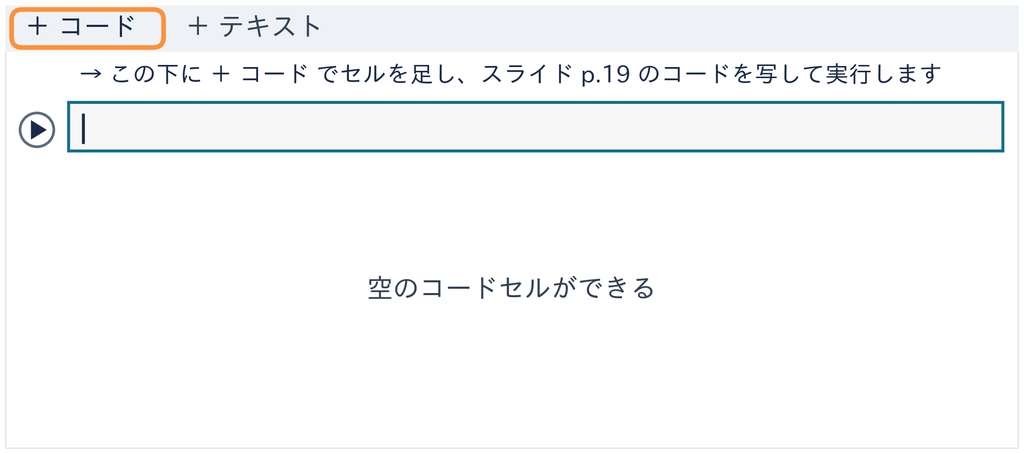

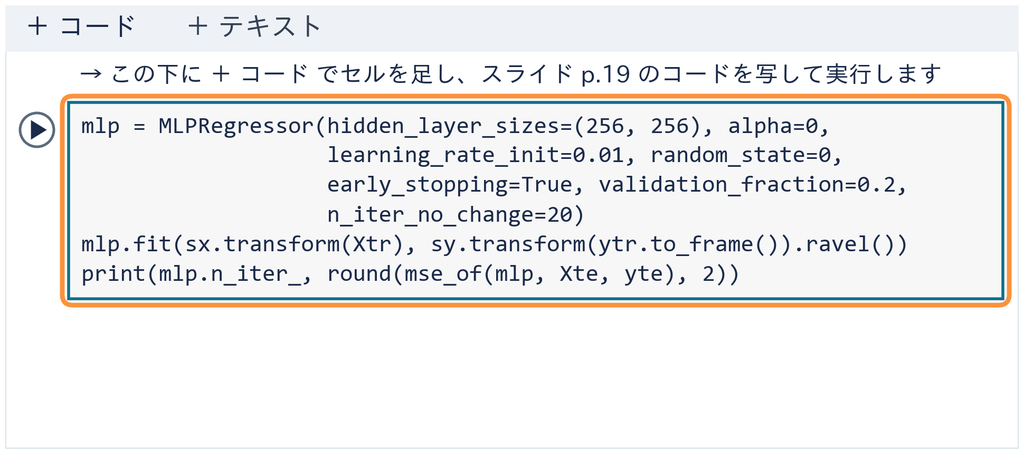

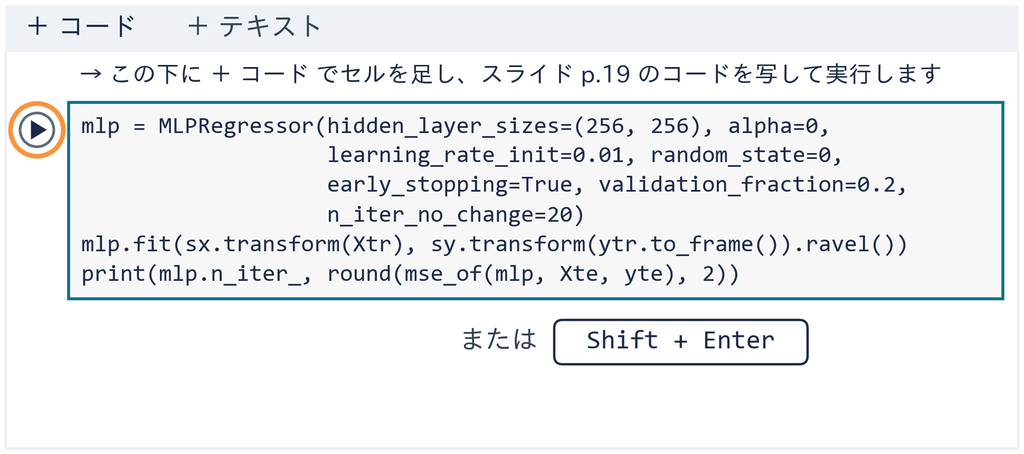

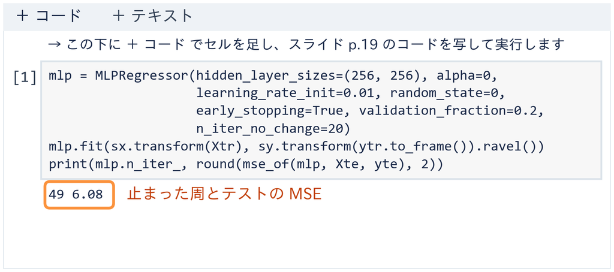

⏸ PAUSE 動画を止めて $2$ 分。`49 6.08` が出たら再生に戻る

## デモ：止める・罰金の実験室

数の話

訓練と検証の誤差（損失と同じ MSE）1500 周ぶん  
（訓練 297・検証 75・α 8 通り）

- **何を見るか**：途中で止める・罰金 α を強めると、  
  2 本の線はどう動くか（止めるだけなら α は 0）
- **図の意味**：青緑の線が訓練の誤差、橙の線が検証の誤差。止めるをオンにすると、  
  破線が止めた周・黒い点が戻る先。右に開き（検証 − 訓練）と検証の誤差
- **操作**：罰金 α のスライダー（8 段）、止めるのオン・オフ、戻す（最初の状態へ）。  
  使うのは「止める・罰金」のタブだけ

ミッション 止めるをオンに。止めた周と、  
戻った先の周・検証の誤差を手元に書く

※ 次のスライドへ進むときは、デモの枠の外を一度クリックしてから ← → キーを押す

[interactive chart not shown]

## まとめ

- 学習曲線：訓練と検証の損失を、1 周ごとに並べた 2 本の線
- NN も回しすぎると覚える。訓練は下がり続け、  
  検証は底を打って上がる
- 早期終了：検証の底で止めて底の周の重みに戻す  
  （`early_stopping=True`）
- この授業の外で：NN の結果を書くときは「何周回したか」より  
  「検証の底で止めたか」を書く

回しすぎは、検証の線で見つけて止められた  
残った問い：止めるのは回す回数で止めるやり方。  
重みの大きさそのものを抑えられないか。これを次のトピックで見る

経済データとプログラミングII

第10回 — Topic02

ニューラルネットの正則化

重みに Ridge と同じ罰金を掛ける

## 第10回の道のり

1

見つけて止める

実習：実行 データを読む準備

実習：実行 分けてそろえる準備

実習：実行 学習曲線の準備

演習 10-1 学習曲線の読み取り

実習：写経 早期終了の 3 つの引数

2

罰金を掛ける

実習：写経 罰金つきの学習

演習 10-2 罰金の強さの変更

3

選んで比べる

実習：実行 候補と道具の準備

実習：写経 グリッドサーチ

演習 10-3 Ridge の α の選択

いまココ。止める以外に、重みの大きさそのものを抑える方法を見る

## このトピックで学ぶこと

- **ここまで**：早期終了は、回す回数（時間）で止めるやり方だった
- **でも**：止める周は、くじで 75 周にも 133 周にも動いた  
  前に、曲げすぎた 10 次の曲線は、次数を下げずに罰金で抑えた（Ridge）
- **問い**：NN の重みにも、同じ罰金を掛けられないか
- **進め方**：前半は 5 人の表（E さんを隠す）、後半で景気動向指数

そこで、NN の重みに罰金を掛ける（**重み減衰**・正則化の 1 つ）

## 4 人の NN と罰金の強さ

前のトピックの NN（A〜D の 4 人で 3000 周回しきる）に、罰金の強さ $\alpha$ を 5 段で掛ける

[figure not shown]

$\alpha$ を強めると、E さんの見込みは −2.0 → −1.4 → 1.7 → 5.8 → 6.75（実際は 3）  
強すぎると 4 人の平均 6.75 の水平線。前に出てきた 10 次＋罰金と同じ形

## ◼ 重み減衰

**重み減衰：NN の重みに掛ける、Ridge と同じ罰金**

定義

$$\text{最小にするもの} = \text{残差の二乗の和} + \alpha \times \text{重みの二乗の和}$$

**Ridge**：同じ形で、罰金の相手は係数（前に出てきた）

**重み減衰**：罰金の相手は NN の重み（前の回の折れ目の位置や急さを決める数）  
$\alpha$ は罰金の強さ（0 なら罰金なし）

**減衰**：罰金に押されて、重みが 0 の方へ縮むこと（下の図・同じ 4 人の NN）  
なぜ小さい重みが得になるかは、次のページの小さな例で

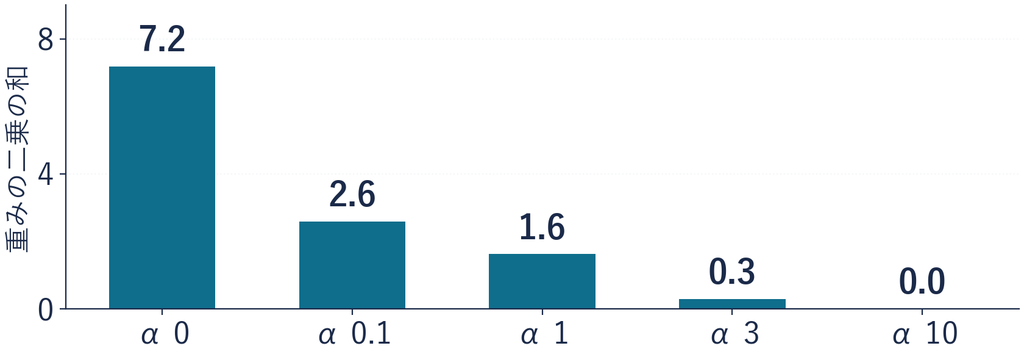

## 小さい重みが得になる例

作った小さな数で、2 つの NN の「最小にするもの」を比べる

|  | 重みが大きい NN （手元にぴったり） | 重みが小さい NN （少し外れる） |
| --- | --- | --- |
| 残差の二乗の和（前） | 3 | 5 |
| 重みの二乗の和（後） | 4 | 1 |

罰金なし（$\alpha$ 0）：$3 + 0 \times 4 = 3$、$5 + 0 \times 1 = 5$ → 重みが**大きい**ほうが小さい

罰金あり（$\alpha$ 1）：$3 + 1 \times 4 = 7$、$5 + 1 \times 1 = 6$ → 重みが**小さい**ほうが小さい

罰金が効くと、少し外れても重みを小さくしたほうが得

## ✋ たしかめ 罰金と乖離

たしかめ

今度は景気動向指数で。罰金を 0 から 0.1 にすると、乖離は

- **乖離**：テストの MSE − 訓練の MSE  
  （前に $R^2$ で見た差を MSE で。大きいほど覚えすぎ）
- **条件**：訓練 372 か月・テスト 125 か月・前のトピックと同じネットワーク
- **回し方**：1000 周を止めずに回しきる（罰金だけの効き目を見るため）
1. **ⓐ** 縮む **ⓑ** ほぼ同じ **ⓒ** 広がる

⏸ PAUSE 動画を止めて $1$ 分。選んだら再生に戻る

## ★ 罰金の有無と乖離

たしかめの答えは **ⓐ 縮む**

[figure not shown]

乖離は 4.5 から 1.6 へ、約 3 分の 1。テストは 5.8 と 5.7 でほぼ同じ  
罰金なしは手元 1.3 なのに見ていない月は 5.8＝手元の成績で見誤る  
罰金ありは手元 4.1・見ていない月 5.7 で、差が小さい

| テストの MSE（条件が違う） | 学ぶ月 | 周の数 | くじ |
| --- | --- | --- | --- |
| 前のトピックの回しきり（約 10） | 297 | 1500 | 0 |
| ここの罰金なし（5.8） | 372 | 1000 | 42 |

## 写経 2 罰金つきの学習

```python
mlp = MLPRegressor(hidden_layer_sizes=(256, 256),
                   alpha=0.1, learning_rate_init=0.01, max_iter=1000,
                   n_iter_no_change=1000, random_state=42)
mlp.fit(sx.transform(Xtr), sy.transform(ytr.to_frame()).ravel())
print(round(mse_of(mlp, Xtr, ytr), 1), round(mse_of(mlp, Xte, yte), 1))
```

| 行 | 部品 | 渡すもの | できるもの |
| --- | --- | --- | --- |
| 1 | **作る** `MLPRegressor` | 前と同じネットワーク | モデル `mlp` |
| 2-3 | **罰金と回しきり** | `alpha=0.1`：罰金の強さ `max_iter`：周の上限 `n_iter_no_change`： 止める判定を待つ周 | どちらも 1000 ＝最後まで回しきる 42 は最初の重みの くじの番号 |
| 4 | **学ぶ** `.fit` | そろえた訓練 372 か月 | 罰金つきの重み |
| 5 | **見る** `mse_of` | 訓練とテスト（小数 1 桁） | `4.1 5.7` |

※ `Ridge` と同じ名前の罰金。既定は `alpha=0.0001`（最初から小さな罰金）  
※ 赤い `ConvergenceWarning` は 1000 周で打ち切った印で、失敗ではない  
※ 出るまでの時間は状況で違う。気長に待つ

## コードセルの写経と実行

1. **＋ コード**で空のセルを足す  
   （案内の文の下）
2. 写経 2 の 5 行を上  
   から写す
3. **▶** か **Shift + Enter** で実行  
   （Mac は Shift + return）
4. 出力 `4.1 5.7`  
   （訓練とテスト）を見る

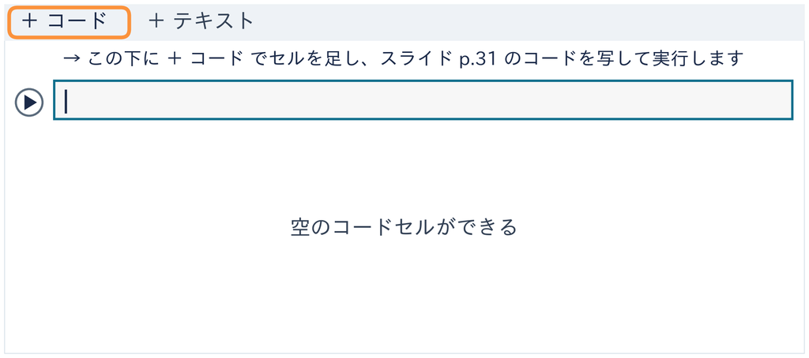

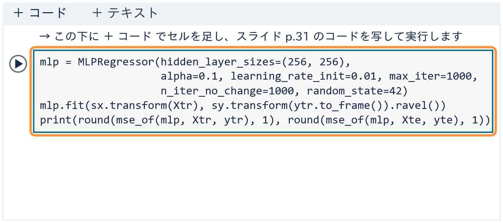

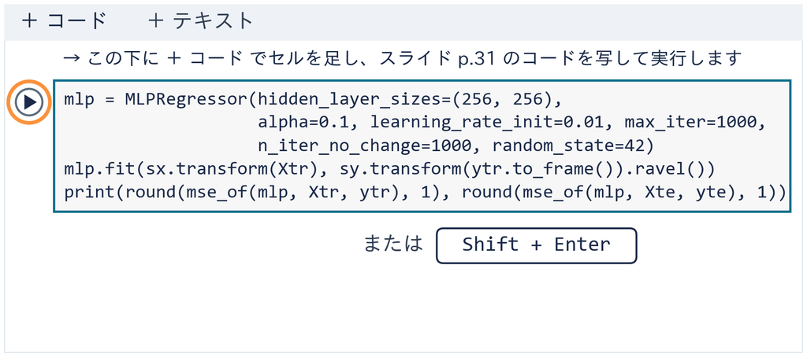

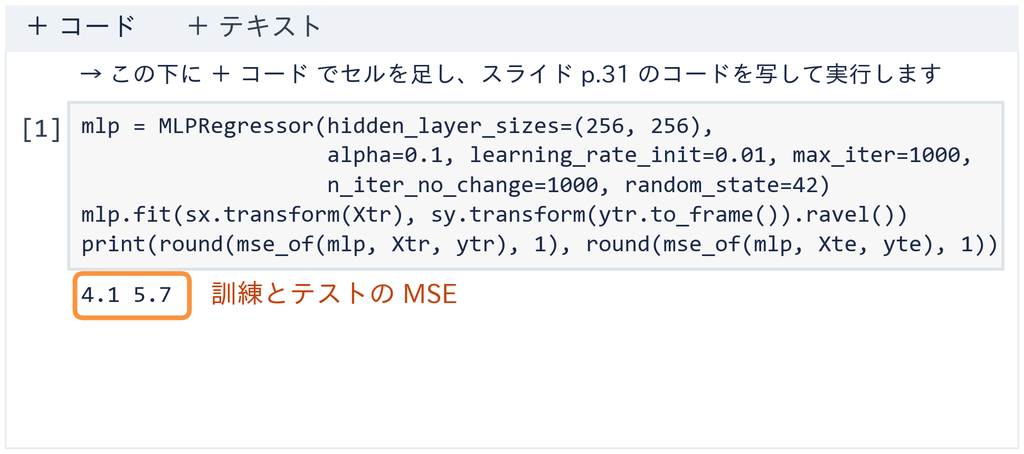

⏸ PAUSE 動画を止めて $2$ 分。`4.1 5.7` が出たら再生に戻る

## 演習 10-2 罰金の強さの変更

演習 10-2

罰金を 3 に強めると、テストの MSE は

```python
mlp = MLPRegressor(hidden_layer_sizes=(256, 256),
                   alpha=3, learning_rate_init=0.01, max_iter=1000,
                   n_iter_no_change=1000, random_state=42)
```

1. **先に考える**：$\alpha$ 0.1 のテストは 5.7  
   $\alpha$ 3 では ⓐ もっと小さい ⓑ ほぼ同じ ⓒ 大きい
2. **写して変える**：写経 2 の 5 行を新しいセルに写し  
   2 行目の `0.1` を `3` に（変えるのは 1 か所）
3. **終わり**：答え欄に ⓐ〜ⓒ と、訓練・テスト・乖離の 3 つの数

⏸ PAUSE 動画を止めて $3$ 分。答えを書いたら再生に戻る

## 演習 10-2 の答え

答えは **ⓒ 大きい**。出力は `6.9 9.4`（乖離 9.4 − 6.9 ＝ 2.5）

✕ 罰金は強いほど安全

覚えすぎを防ぐなら  
強いほど良さそうに見える

○ 強すぎると覚えるべき形まで消える

$\alpha$ 3 のテストは 9.4  
前に出した重回帰の  
テスト 10.43 に近づく

$\alpha$ 0 → 0.1 で乖離は縮んだ。  
強めすぎると乖離もテストも悪くなる（2.5・9.4）  
罰金は点を上げる道具ではなく、覚えすぎない形にする道具

## デモ：止める・罰金の実験室

数の話

訓練と検証の誤差（損失と同じ MSE）1500 周ぶん  
（訓練 297・検証 75・α 8 通り）

- **何を見るか**：途中で止める・罰金 α を強めると、  
  2 本の線はどう動くか（止めるだけなら α は 0）
- **図の意味**：青緑の線が訓練の誤差、橙の線が検証の誤差。止めるをオンにすると、  
  破線が止めた周・黒い点が戻る先。右に開き（検証 − 訓練）と検証の誤差
- **操作**：罰金 α のスライダー（8 段）、止めるのオン・オフ、戻す（最初の状態へ）。  
  使うのは「止める・罰金」のタブだけ

ミッション α を右へ。検証の誤差がいちばん小さい α と、  
そのときの開きを手元に書く

※ 次のスライドへ進むときは、デモの枠の外を一度クリックしてから ← → キーを押す

[interactive chart not shown]

## 前に見た道具との対応表

| 役 | 前に見た道具 | NN |
| --- | --- | --- |
| **曲げ方を決める設定** | 多項式の次数 | 回す回数 （周）・ノード数 |
| **罰金** | `Ridge` の `alpha` | `MLPRegressor` の `alpha` （重み減衰） |
| **見張り・選び方** | 交差検証（CV の誤差） | 検証で止める （早期終了）・交差検証 （次のトピック） |

罰金は Ridge の alpha そのまま。NN で新しく増えたのは、  
検証で見張って「止める」だけ

## まとめ

- 重み減衰：NN の重みに、Ridge と同じ罰金を掛ける（`alpha`）
- 罰金を掛けると乖離が縮む（4.5 → 1.6）。  
  強すぎると覚えるべき形まで消える
- 罰金は、覚えすぎない形にする道具。  
  テストの点を大きく上げる道具ではない

罰金は NN の重みにも効いた。止めると罰金は一緒に使える  
残った問い：止め方・$\alpha$・ノード数…設定が多い。  
どう決めるか。これを次のトピックで見る

経済データとプログラミングII

第10回 — Topic03

ニューラルネットの  
ハイパーパラメータ調整

設定を交差検証で選び、重回帰・Ridge と比べる

## 第10回の道のり

1

見つけて止める

実習：実行 データを読む準備

実習：実行 分けてそろえる準備

実習：実行 学習曲線の準備

演習 10-1 学習曲線の読み取り

実習：写経 早期終了の 3 つの引数

2

罰金を掛ける

実習：写経 罰金つきの学習

演習 10-2 罰金の強さの変更

3

選んで比べる

実習：実行 候補と道具の準備

実習：写経 グリッドサーチ

演習 10-3 Ridge の α の選択

いまココ。たくさんの設定を、どう選んでどう比べるかを見る

## このトピックで学ぶこと

- **ここまで**：止め方（早期終了）と罰金の強さ $\alpha$ を見た。  
  前の回のノード数と学習率もある  
  （学習率：大きすぎると谷を飛び越え、小さすぎると着かない）
- **でも**：決める設定が 4 つもある。テストを見て選ぶと、  
  テストが採点に使えなくなる
- **問い**：設定が何個あっても、前の作法  
  （候補を並べ、交差検証の誤差がいちばん小さいものを選ぶ）で選べないか
- **進め方**：前半は 5 人の表、後半で景気動向指数

そこで、設定の組を全部試して選ぶ（**グリッドサーチ**）

## ◼ ハイパーパラメータ

用語

**ハイパーパラメータ**：`fit` の前に人が決める設定  
（ノード数・罰金 $\alpha$・学習率・止め方）

**重み・バイアス**：`fit` が坂を下って決める数

**ハイパーパラメータ**：人が決める。選ぶのは訓練の中の交差検証

**前に出てきた型**：重みは訓練で求める → 設定は交差検証で選ぶ  
→ 最後にテストで 1 回だけ採点する

12 組からテストで選ぶと、たまたまテストに合った組を選ぶ。  
だからテストでは選ばない

## 5 人で交代する 2 × 2 の表

前に出てきた 5 人で 1 人ずつ交代する交差検証で、  
ノード数 2 通り × $\alpha$ 2 通りの 4 組を試す  
（4 人でわざと止めずに 3000 周回しきり、残る 1 人を見込む。これを 5 回して平均）

[figure not shown]

いちばん小さいのはノード 20・$\alpha$ 1 の 5.28。前に出てきた直線の 5.77 とほぼ同じ  
5 人では、NN も直線と変わらない。罰金なしの 2 マス（12.29・9.62）は大きく外す

## ◼ グリッドサーチ

**グリッドサーチ：設定の組を全部試し、交差検証でいちばん良い組を選ぶ**

手順

STEP 1：候補の組を並べる（例：ノード数 3 通り × $\alpha$ 4 通り ＝ 12 組）

STEP 2：組ごとに、訓練を 5 つに分けた交差検証で CV の誤差を測る

STEP 3：CV の誤差がいちばん小さい組を選ぶ

STEP 4：選んだ組で 372 か月を全部学び直し、テストで 1 回だけ採点する

交差検証で学ぶ回数は、組の数 × 分割の数  
（12 組 × 5 分割 ＝ 60 回）。だから候補は少なめに  
グリッド：格子。組を表のマス目に並べて、全部のマスを試すことから

## よくある失敗 y のそろえ忘れ

今度は景気動向指数で、そろえ方を 3 通りに（ノード 64 個 × 2 層・300 周・くじ 3 通り）

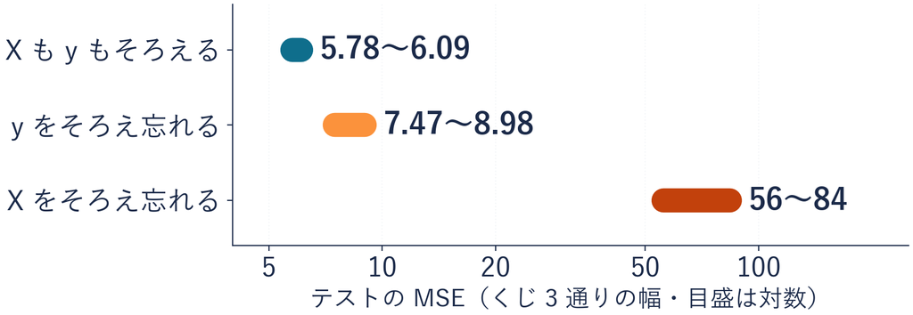

**✕ y はそのまま**：当てたいのは一致指数そのもの（100 前後）なので  
そろえなくてよさそうに見える

**○ y もそろえる**：最初の見込みはほぼ 0 から始まる  
そろえて学び、最後に元の単位へ戻す（前の回と同じ）

## 候補と道具の準備のセル

```python
from sklearn.model_selection import GridSearchCV, KFold
from sklearn.pipeline import make_pipeline
from sklearn.linear_model import Ridge
pipe = make_pipeline(StandardScaler(), MLPRegressor(
    learning_rate_init=0.01, max_iter=1000, early_stopping=True,
    validation_fraction=0.2, n_iter_no_change=20, random_state=0))
hiddens = [(8,), (64, 64), (256, 256)]
alphas = [0.0001, 0.01, 0.1, 1]
grid = {"mlpregressor__hidden_layer_sizes": hiddens,
        "mlpregressor__alpha": alphas}
kf = KFold(5, shuffle=True, random_state=42)
ytr_s = sy.transform(ytr.to_frame()).ravel()
print(len(hiddens) * len(alphas))
```

ノートの準備のセル（写さず実行）  
`make_pipeline`：X のそろえ方と NN を 1 つに（学ぶ側ごとにそろう）  
`ytr_s`：訓練 372 か月で 1 回だけそろえた y（簡単のため）  
候補の名前は「部品名__引数名」・学習率は 0.01 に固定・`12` と出る  
11 行目の 42 は混ぜるくじの番号

## 写経 3 グリッドサーチ

```python
gs = GridSearchCV(pipe, grid, cv=kf, scoring="neg_mean_squared_error")
gs.fit(Xtr, ytr_s)
print(gs.best_params_, round(-gs.best_score_ * sy.var_[0], 2))
pred = sy.inverse_transform(gs.predict(Xte).reshape(-1, 1)).ravel()
print(round(mean_squared_error(yte, pred), 2))
```

| 行 | 部品 | 渡すもの | できるもの |
| --- | --- | --- | --- |
| 1 | STEP 1・2 用意 `GridSearchCV` | モデル `pipe`・候補 `grid`・分け方 `kf`・物差し（MSE） | 探す道具 `gs` |
| 2 | **STEP 2・3 試して選ぶ** `.fit` | 訓練 372 か月（そろえた y） | 60 回学び、いちばん良い組で学び直す |
| 3 | **STEP 3 読む** `best_params_` | 選んだ組・CV の誤差 （元の単位に戻す） | `(256, 256)`・`0.0001`・`6.62` |
| 4-5 | **STEP 4 採点** | テスト 125 か月を 1 回だけ | `6.06` |

※ `scoring` は MSE にマイナスを付けた点（大きいほど良い）・`-` で戻す  
※ そろえた y の誤差なので、分散 `sy.var_[0]` を掛けると元の単位に戻る  
※ 学ぶ 4 つの中の 2 割は止め時の見張り・テスト 125 は最後に 1 回  
※ 出るまでの時間は状況で違う。気長に待つ

## コードセルの写経と実行

1. **＋ コード**で空のセルを足す  
   （案内の文の下）
2. 写経 3 の 5 行を上  
   から写す
3. **▶** か **Shift + Enter** で実行  
   （Mac は Shift + return）
4. CV の誤差

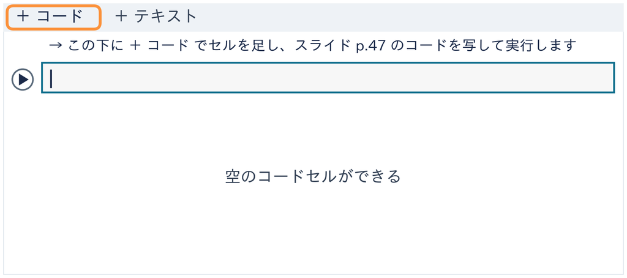

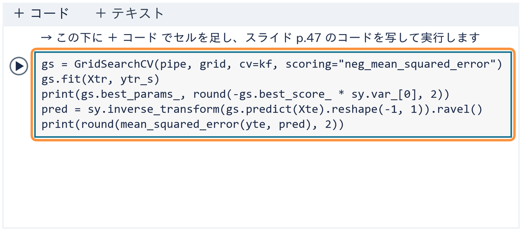

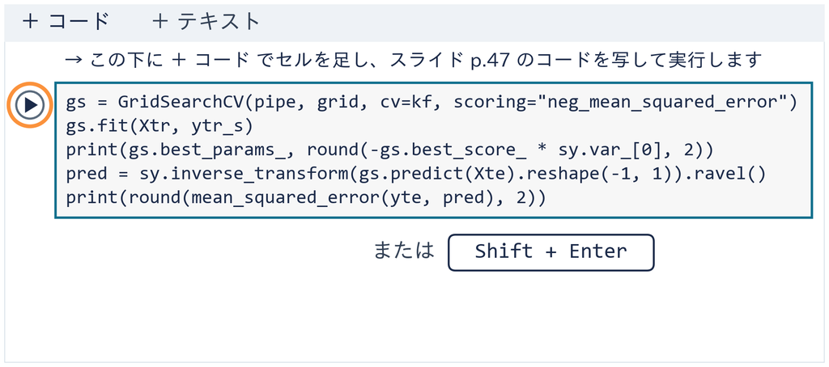

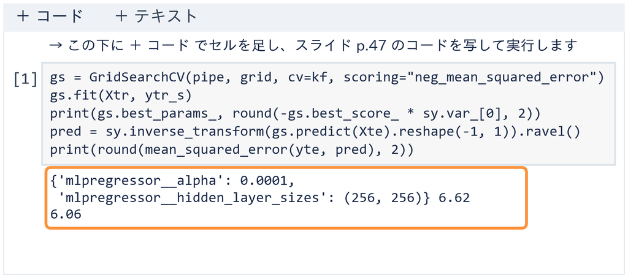

⏸ PAUSE 動画を止めて $3$ 分。`6.06` が出たら再生に戻る

## 演習 10-3 Ridge の α の選択

演習 10-3

同じ道具で Ridge の α を選ぶと、テストの MSE は

```python
pipe = make_pipeline(StandardScaler(), Ridge())
grid = {"ridge__alpha": [0.1, 1, 10, 100]}
```

1. **先に考える**：重回帰の 10.43（前のトピックと同じ分け方のテスト）と比べて  
   ⓐ ずっと小さい ⓑ ほぼ同じ ⓒ 大きい
2. **書き足して実行**：上の 2 行を新しいセルで実行し  
   写経 3 のセルを ▶ でもう一度（NN の 6.06 は先にメモ）
3. **終わり**：答え欄に ⓐ〜ⓒ と、選んだ $\alpha$・CV の誤差・テストの MSE

⏸ PAUSE 動画を止めて $3$ 分。答えを書いたら再生に戻る

## 演習 10-3 の答え

答えは **ⓑ ほぼ同じ**。出力は `{'ridge__alpha': 1} 7.67` と `10.41`

**選んだ $\alpha$**：1（CV の誤差 7.67。$\alpha$ の目盛りは道具ごとに違う）

**テスト**：10.41。重回帰の 10.43 とほぼ同じ

**効かない訳**：罰金は係数を 0 の方へ縮める  
今回は縮めても、テストはほぼ変わらなかった  
先行と遅行の相関は 0.596 で、似すぎてもいない

## ★ 同じ物差しでの比べ

同じ分け方（訓練 372・テスト 125）・同じ物差し（テストの MSE）で並べる

[figure not shown]

NN は 6.06。重回帰・Ridge の 10.4 前後から大きく下がった  
罰金の Ridge では縮まなかった。直線にならない関係を、NN がとらえた可能性がある

## AI の提案の 3 つの誤り

AI の提案（数は架空）

学習率と止め方は、テストの MSE がいちばん小さい組を選んだ  
標準化は 497 か月全体で行った。テストの MSE は 4.8

**誤り 1**：テストで選んだ → 設定は訓練の中の交差検証で選ぶ

**誤り 2**：全体で標準化した → テストの月の平均が学ぶ側に混ざる（リーク）  
そろえ方も訓練だけで決める

**誤り 3**：その 4.8 は選ぶのに使ったテストの点 → 見ていないデータへの当たりではない

## デモ：チューニング大会

数の話

前もって Python で計算した 40 本の曲線（学習率 5 段 × α 8 段・1500 周）。  
右の数は、止めるがオフなら 1500 周目、オンなら戻った先の検証の誤差

- **何を見るか**：学習率と罰金の組で、検証の誤差はどこまで下がるか  
  （早さのため、交差検証の代わりに検証 1 本で選ぶ）。テストは最後に 1 回だけ
- **図の意味**：青緑の線が訓練の誤差、橙の線が検証の誤差。  
  右に検証の誤差と自己ベスト、採点の後はテストの誤差
- **操作**：学習率のスライダー（5 段）、罰金 α のスライダー（8 段）、  
  止めるのオン・オフ、採点（1 回だけ）、戻す

ミッション 検証の誤差の自己ベストを探し、最後に採点を 1 回だけ押す

※ 次のスライドへ進むときは、デモの枠の外を一度クリックしてから ← → キーを押す

[interactive chart not shown]

## 第 10 回のまとめ

**見つける**：学習曲線の 2 本。訓練は下がり続け、検証は底を打って上がる

**止める**：早期終了。検証の底で止め、底の周の重みに戻す

**抑える**：重み減衰。NN の重みに Ridge と同じ罰金

**選ぶ**：グリッドサーチ。設定の組を訓練の中の交差検証で選ぶ  
テストは最後に 1 回

**比べる**：同じ分け方・同じテストの MSE で、NN 6.06・重回帰 10.43・Ridge 10.41

NN も回し続けると覚える。検証を見張って止め、  
重みに罰金を掛け、設定は交差検証で選ぶ  
前に出てきた「見ていないデータで確かめる目」  
は、NN でもそのまま使えた

この授業の外で：卒論で NN を使ったら  
「設定は訓練の中の交差検証で選び、テストは最後に 1 回だけ見た」と 1 行書く